## Agenda

- get current date/time
- understand date/time classes in R
- date arithmetic
- timezones & daylight savings
- date/time formats
- date/time parsing
- date/time components
- create, update & verify date/time objects
- intervals, duration and period

## Prerequisites

- completed [Introduction to R](https://rsquared-academy.thinkific.com/courses/introduction-to-r) course
- laptop/desktop with [R](https://www.r-project.org/) & [RStudio](https://www.rstudio.com/) installed
- internet connection to use [RStudio Cloud](https://rstudio.cloud/)

## Resources

- [Slides](https://slides.rsquaredacademy.com/data-wrangling/lubridate/datetime.html#/section)
- [Blog Post](https://blog.rsquaredacademy.com/handling-date-and-timr-in-r/)
- [Code & Data](https://github.com/rsquaredacademy-education/online-courses/)
- [RStudio Cloud](https://rstudio.cloud/project/1072419)
- [Online Course](https://rsquared-academy.thinkific.com/courses/handling-date-and-time-in-r)

## Current Date/Time

| Function | Description |
| --- | --- |
| `Sys.Date()` | Current Date |
| `lubridate::today()` | Current Date |
| `Sys.time()` | Current Time |
| `lubridate::now()` | Current Time |
| `lubridate::am()` | Whether time occurs in am? |
| `lubridate::pm()` | Whether time occurs in pm? |
| `lubridate::leap_year()` | Check if the year is a leap year? |

## Your Turn

- get current date
- get current time
- check whether the time occurs in am or pm?
- check whether the following years were leap years
  - 2018
  - 2016

## Case Study - Data

```r
transact <- read_csv('https://raw.githubusercontent.com/rsquaredacademy/datasets/master/transact.csv')
```

```
## # A tibble: 2,466 x 3
##    Invoice    Due        Payment
##    <date>     <date>     <date>
##  1 2013-01-02 2013-02-01 2013-01-15
##  2 2013-01-26 2013-02-25 2013-03-03
##  3 2013-07-03 2013-08-02 2013-07-08
##  4 2013-02-10 2013-03-12 2013-03-17
##  5 2012-10-25 2012-11-24 2012-11-28
##  6 2012-01-27 2012-02-26 2012-02-22
##  7 2013-08-13 2013-09-12 2013-09-09
##  8 2012-12-16 2013-01-15 2013-01-12
##  9 2012-05-14 2012-06-13 2012-07-01
## 10 2013-07-01 2013-07-31 2013-07-26
## # ... with 2,456 more rows
```

## Case Study

- extract date, month and year from Due
- compute the number of days to settle invoice
- compute days over due
- check if due year is a leap year
- check when due day in february is 29, whether it is a leap year
- how many invoices were settled within due date
- how many invoices are due in each quarter
- what is the average duration between invoice date and payment date

## Date/Time Classes

- `Date`
- `POSIXct`
- `POSIXlt`

## ISO 8601 Format

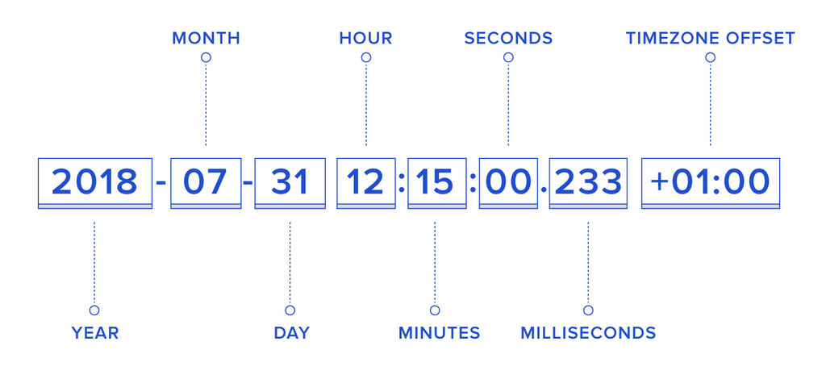

## POSIXlt

| Component | Description |
| --- | --- |
| `sec` | Second |
| `min` | Minute |
| `hour` | Hour of the day |
| `mon` | Month of the year (0-11 |
| `zone` | Timezone |
| `wday` | Day of week |
| `mday` | Day of month |
| `year` | Years since 1900 |
| `yday` | Day of year |
| `isdst` | Daylight saving flag |
| `gmtoff` | Offset is seconds from GMT |

## Your Turn

R 1.0.0 was released on `2000-02-29 08:55:23 UTC`. Save it as

- `Date` using character
- `Date` using origin and number
- `POSIXct`
- `POSIXlt` and extract
  - month day
  - day of year
  - month
  - zone
- ISODate

## Date Arithmetic - Course Length

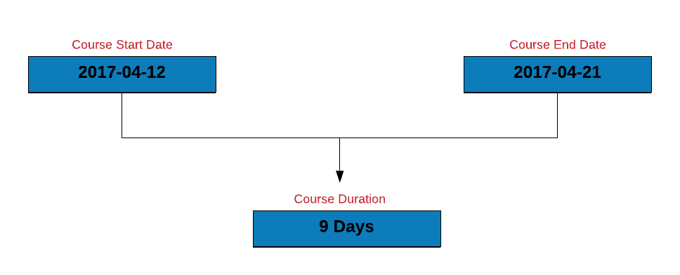

## Date Arithmetic - Shift Date

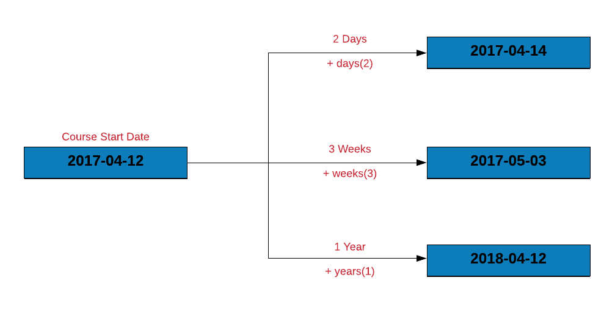

## Your Turn

- compute the length of a vacation which begins on `2020-04-19` and ends on `2020-04-25`
- recompute the length of the vacation after shifting the vacation start and end date by `10` days and `2` weeks
- compute the days to settle invoice and days overdue from the `receivables.csv` data set
- compute the length of employment (only for those employees who have been terminated) from the `hr-data.csv` data set (use date of hire and termination)

## Timezones

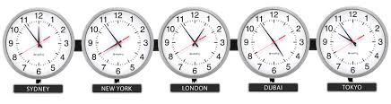

## Daylight Savings

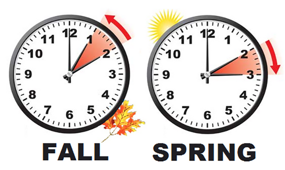

## Your Turn

- check the timezone you live in
- check if daylight savings in on
- check the current time in **UTC** or a different time zone

## Date & Time Formats

- December 12, 2019"
- 12th Dec, 2019
- Dec 12th, 19
- 12-Dec-19
- 2019 December
- 12.12.19

## Conversion Specifications

| Specification | Description | Example |
| --- | --- | --- |
| `%d` | Day of the month (decimal number) | 12 |
| `%m` | Month (decimal number) | 12 |
| `%b` | Month (abbreviated) | Dec |
| `%B` | Month (full name) | December |
| `%y` | Year (2 digit) | 19 |
| `%Y` | Year (4 digit) | 2019 |
| %H | Hour | 8 |
| %M | Minute | 5 |
| %S | Second | 3 |

## Your Turn

Below, we have specified `July 5th, 2019` in different ways. Create the date using `as.Date()` while specifying the correct format for each of them.

- `05.07.19`
- `5-July 2019`
- `July 5th, 2019`
- `July 05, 2019`
- `2019-July- 05`
- `05/07/2019`
- `07/05/2019`
- `7/5/2019`
- `07/5/19`
- `2019-07-05`

## Parse Date & Time

| Date | Specification |
| --- | --- |
| 19-07-05 | `ymd` |
| 2019-07-05 | `ymd` |
| 05-07-2019 | `dmy` |
| 07-05-2019 | `mdy` |

## Your Turn

Below, we have specified `July 5th, 2019` in different ways. Parse the dates using `strptime()` or `parse_date_time()` or any other helper function.

- `July-05-19`
- `JUL-05-19`
- `05.07.19`
- `5-July 2019`
- `July 5th, 2019`
- `July 05, 2019`
- `2019-July- 05`
- `05/07/2019`
- `07/05/2019`
- `7/5/2019`
- `2019-07-05`

## Date & Time Components

- year
- month
- date
- week
- day
- quarter
- semester
- hour
- minute
- second
- timezone

## Year, Month & Week

| Function | Description |
| --- | --- |
| `year()` | Get year |
| `month()` | Get month (number) |
| `month(label = TRUE)` | Get month (abbreviated name) |
| `month(abbr = FALSE)` | Get month (full name) |
| `months()` | Get month |
| `week()` | Get week |

## Day

| Function | Description |
| --- | --- |
| `day` | Get day |
| `mday()` | Day of the month |
| `wday()` | Day of the week |
| `qday()` | Day of quarter |
| `yday()` | Day of year |
| `weekdays()` | Day of week |
| `days_in_month()` | Days in the month |

## Hour, Minute & Seconds

| Function | Description |
| --- | --- |
| `hour()` | Get hour |
| `minute()` | Get minute |
| `second()` | Get second |
| `seconds()` | Number of seconds since `1970-01-01` |

## Quarter & Semester

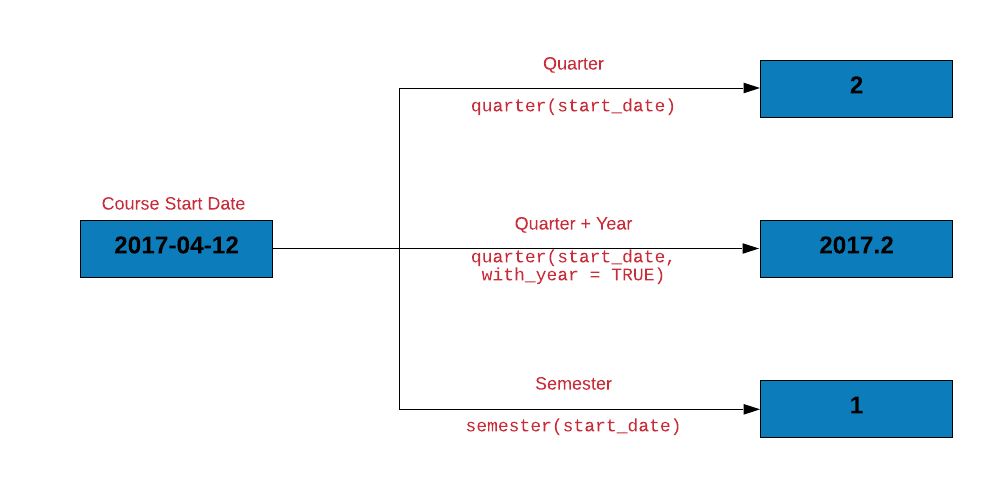

## Quarter & Semester

| Function | Description |
| --- | --- |
| `quarter()` | Get quarter |
| `quarter(with_year = TRUE)` | Quarter with year |
| `quarter(fiscal_start = 4)` | Fiscal starts in April |
| `quarters()` | Get quarter |
| `semester()` | Get semester |

## Case Study - Day, Month & Year

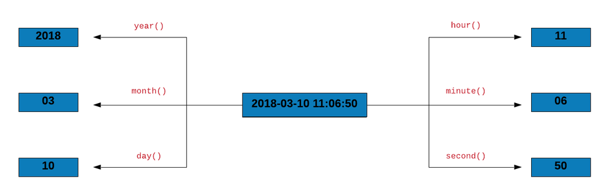

## Case Study - Data Sanitization

Let us do some data sanitization. If the due day happens to be February 29, let us ensure that the due year is a leap year. Below are the steps to check if the due year is a leap year:

- we will extract the following from the due date:
  - day
  - month
  - year
- we will then create a new column `is_leap` which will have be set to `TRUE` if the year is a leap year else it will be set to `FALSE`
- filter all the payments due on 29th Feb
- select the following columns:
  - `Due`
  - `is_leap`

## Your Turn

Get the R release dates using `r_versions()` from the **rversions** package and tabulate the following

- year
- month with label
- weekday with label
- hour
- and quarter

## Create, Update & Verify

- `make_date()`
- `make_datetime()`
- `update()`

## Date Sequence

[output not shown]

## Your Turn

R 2.0.0 was released on `2004-10-04 14:24:38`. Create this date using

- `make_date()`
- `make_datetime()`
- and update to `2013-04-03 07:12:36` (R 3.0.0 release date)

## Interval

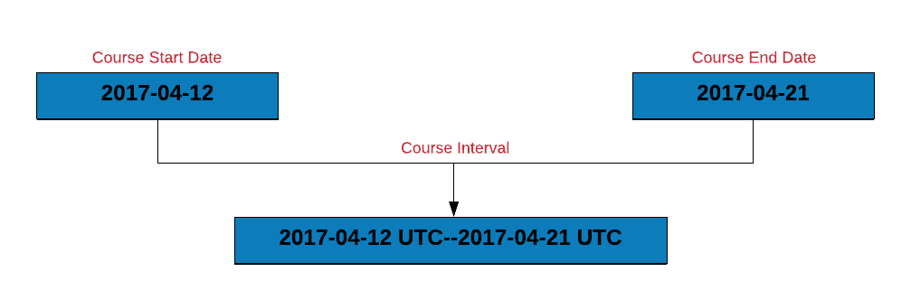

## Shift Interval

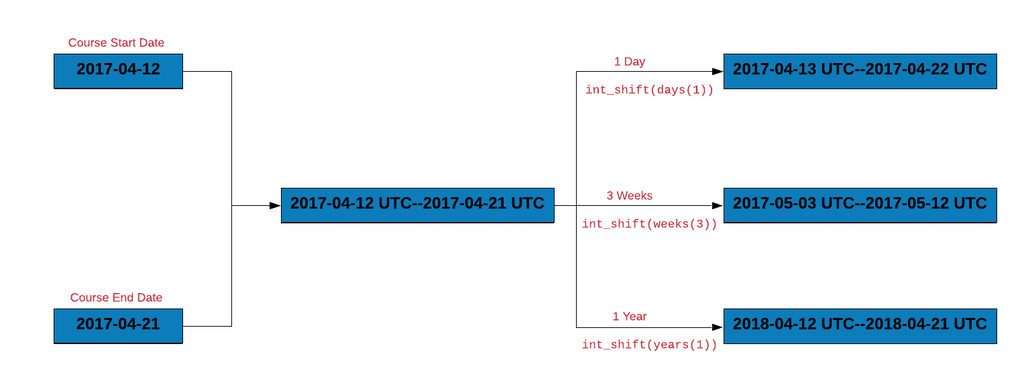

## Interval Overlap

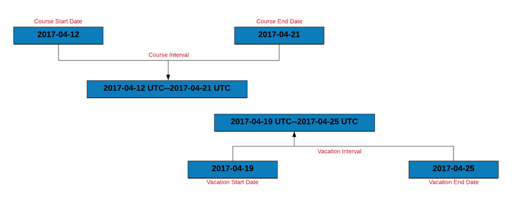

## Case Study

Let us use intervals to count the number of invoices that were settled within the due date. To do this, we will:

- create an interval for the invoice and due date
- create a new column `due_next` by incrementing the due date by 1 day
- another interval for `due_next` and the payment date
- if the intervals overlap, the payment was made within the due date

## Within

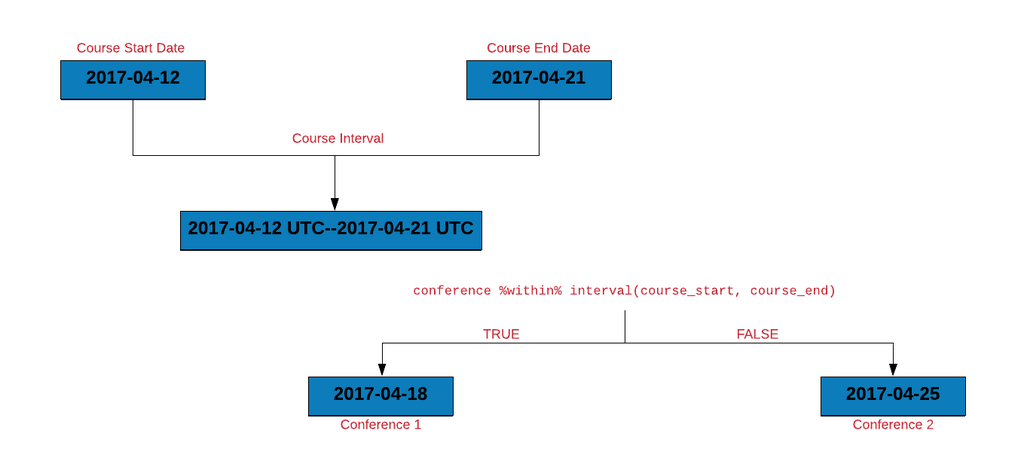

## Case Stduy

Let us use `%within%` to count the number of invoices that were settled within the due date. We will do this by:

- creating an interval for the invoice and due date
- check if the payment date falls within the above interval

## Duration

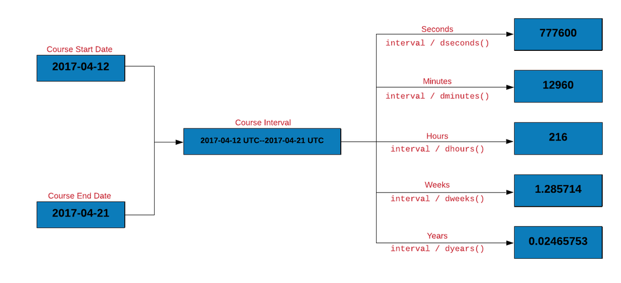

## Period

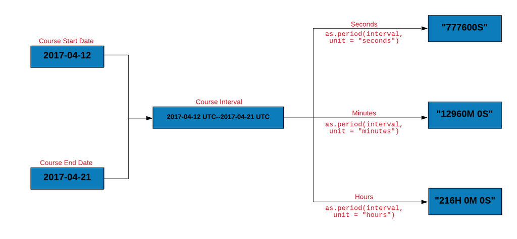

## Time Length

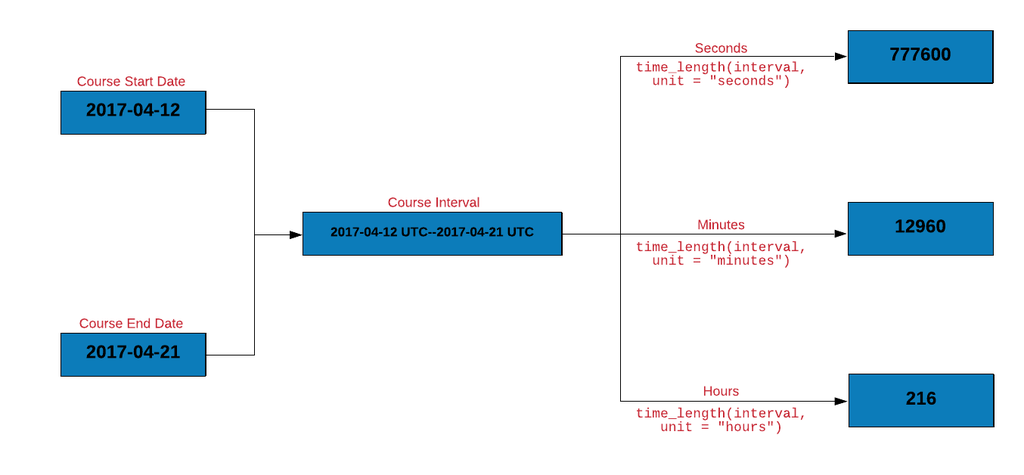

## Rounding Dates

We will explore functions for rounding dates

- to the nearest value using `round_dates()`
- down using `floor_date()`
- up using `ceiling_date()`

## Rounding Dates

The unit for rounding can be any of the following:

- second
- minute
- hour
- day
- week
- month
- bimonth
- quarter
- season
- halfyear
- and year

## Your Turn

- round up R release dates to hours
- round down R release dates to minutes
- rollback R release dates to the beginning of the month

## Connect with Us

- Website (https://www.rsquaredacademy.com/)
- Free Online R Courses (https://rsquared-academy.thinkific.com/)
- R Packages (https://pkgs.rsquaredacademy.com)
- Shiny Apps (https://apps.rsquaredacademy.com)
- Blog (https://blog.rsquaredacademy.com)
- GitHub (https://github.com/rsquaredacademy)
- YouTube (https://www.youtube.com/user/rsquaredin/)
- Twitter (https://twitter.com/rsquaredacademy)
- Facebook (https://www.facebook.com/rsquaredacademy/)
- Linkedin (https://in.linkedin.com/company/rsquared-academy)